# 汽车数据分析报告

数据分析团队

2025年09月07日

# 1 执行摘要

# 2 数据概况

数值变量统计摘要

|  | age | km | weight | hp | cc | doors | price |
| --- | --- | --- | --- | --- | --- | --- | --- |
|  | Min. : 1.00 | Min. : 1 | Min. :1000 | Min. : 69.0 | Min. :1300 | Min. :2.000 | Min. : 4350 |
|  | 1st Qu.:44.00 | 1st Qu.: 43000 | 1st Qu.:1040 | 1st Qu.: 90.0 | 1st Qu.:1400 | 1st Qu.:3.000 | 1st Qu.: 8450 |
|  | Median :61.00 | Median : 63451 | Median :1070 | Median :110.0 | Median :1600 | Median :4.000 | Median : 9900 |
|  | Mean :56.03 | Mean : 68572 | Mean :1072 | Mean :101.5 | Mean :1567 | Mean :4.033 | Mean :10721 |
|  | 3rd Qu.:70.00 | 3rd Qu.: 87042 | 3rd Qu.:1085 | 3rd Qu.:110.0 | 3rd Qu.:1600 | 3rd Qu.:5.000 | 3rd Qu.:11950 |
|  | Max. :80.00 | Max. :243000 | Max. :1320 | Max. :192.0 | Max. :2000 | Max. :5.000 | Max. :32500 |

# 3 分析结果

## 3.1 价格分布

汽车价格呈右偏分布，大部分汽车价格集中在较低水平。

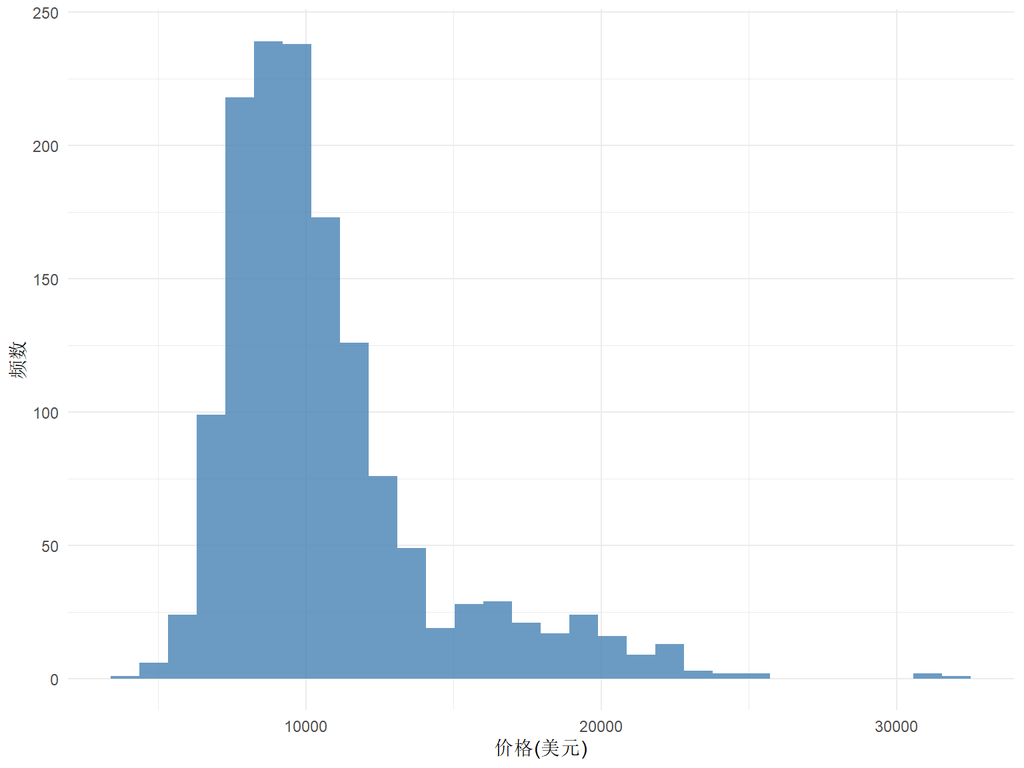

汽车价格分布直方图

## 3.2 车龄与价格的关系

车龄与价格呈现明显的负相关关系，车龄越大，价格越低。这表明汽车折旧是影响价格的重要因素。

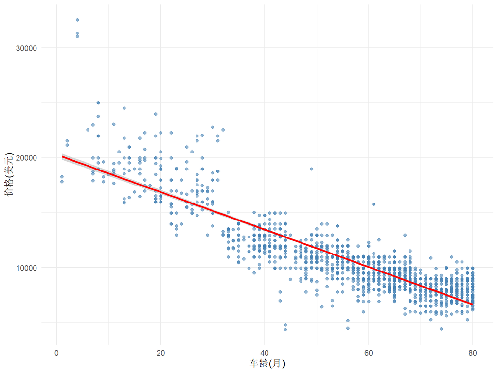

车龄与价格的关系散点图

## 3.3 行驶里程与价格的关系

行驶里程与价格也呈现负相关关系，行驶里程越高，价格越低。这表明行驶里程是影响二手车价格的重要因素。

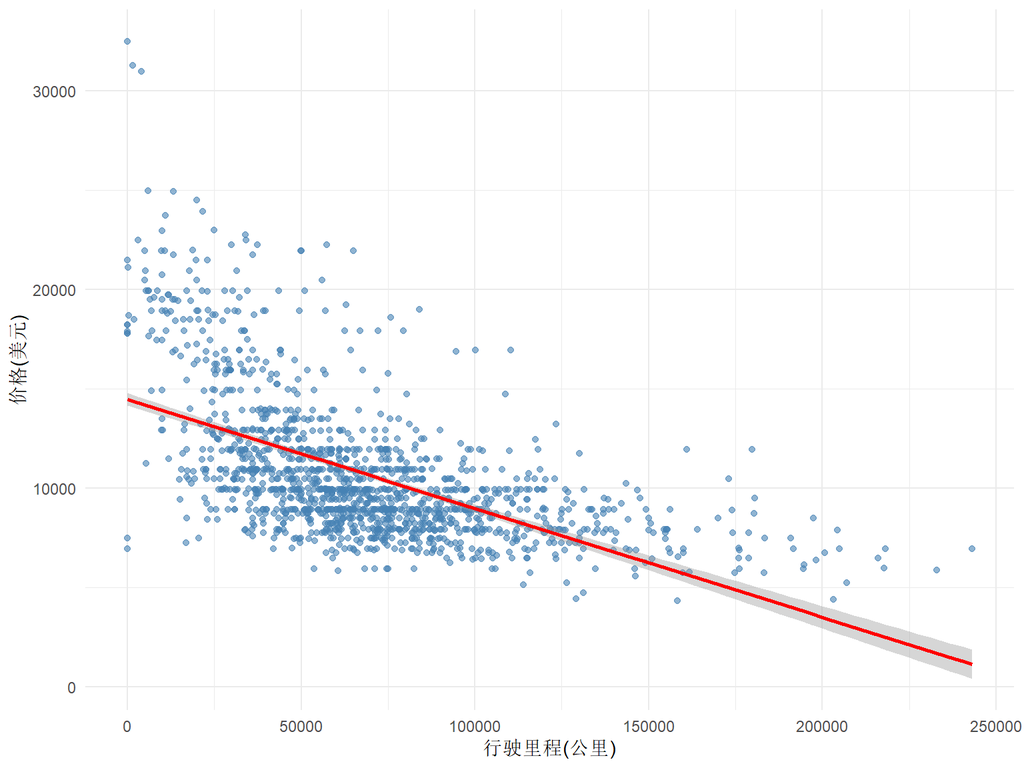

行驶里程与价格的关系散点图

## 3.4 马力与价格的关系

马力与价格呈现正相关关系，马力越大，价格越高。这表明汽车性能对价格有积极影响。

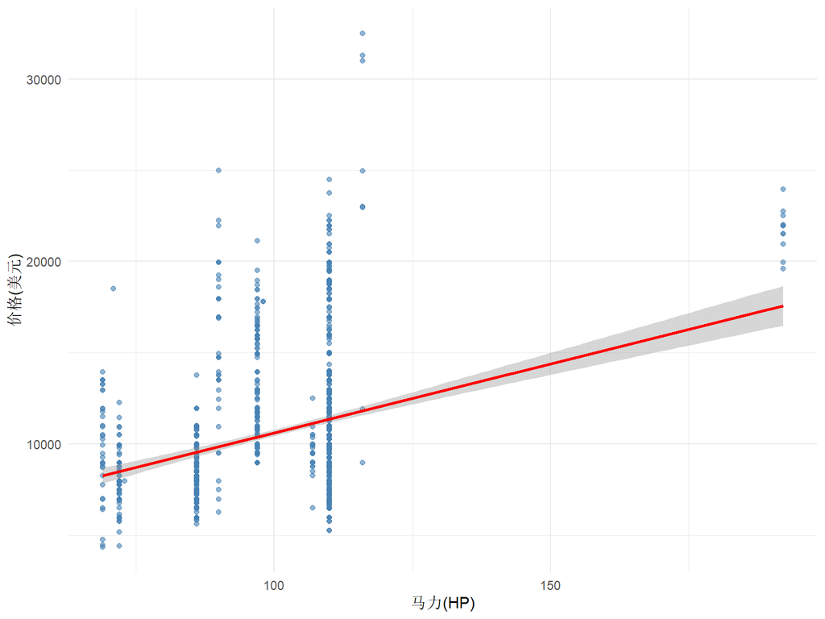

马力与价格的关系散点图

## 3.5 发动机排量与价格的关系

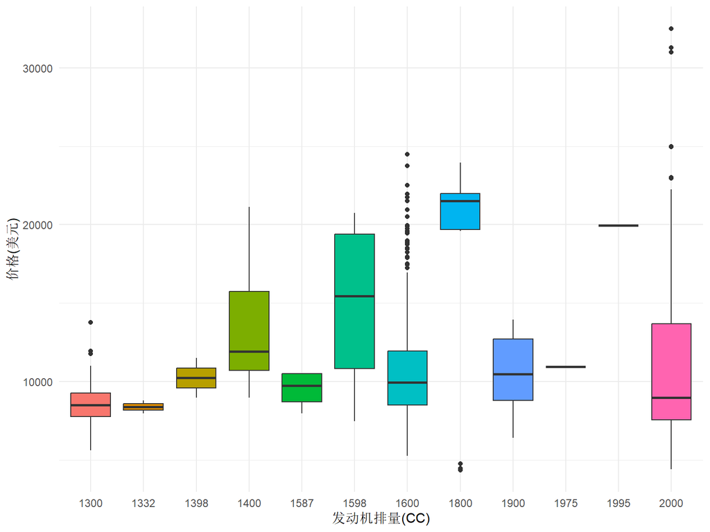

发动机排量与价格的关系箱线图

## 3.6 重量对价格的影响

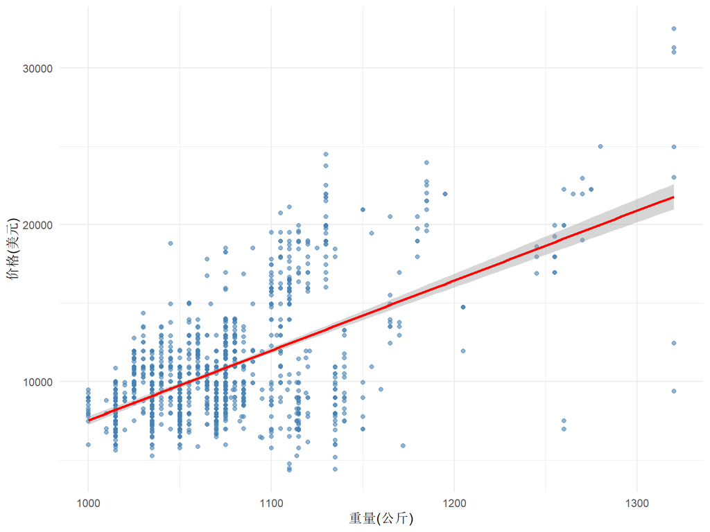

重量对价格的影响散点图

## 3.7 车门数量对价格的影响

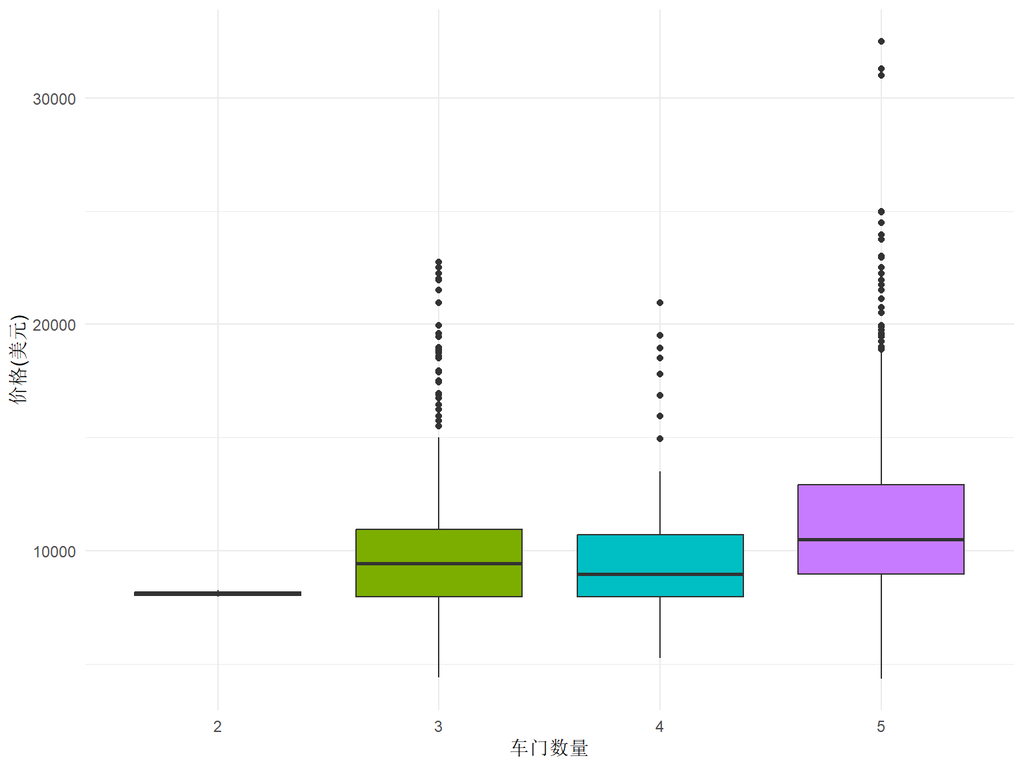

车门数量对价格的影响箱线图

## 3.8 金属漆对价格的影响

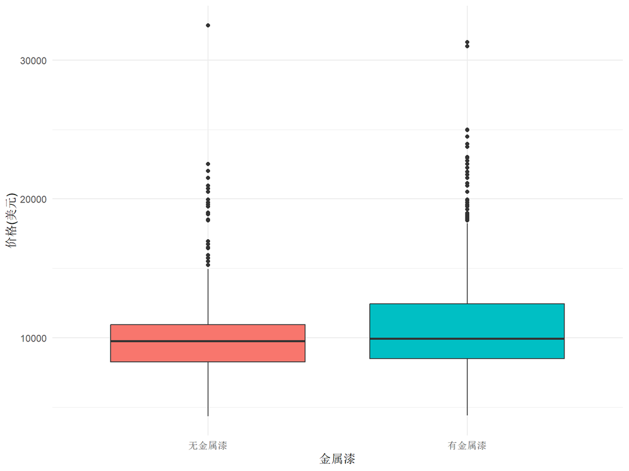

金属漆对价格的影响箱线图

## 3.9 变量相关性分析

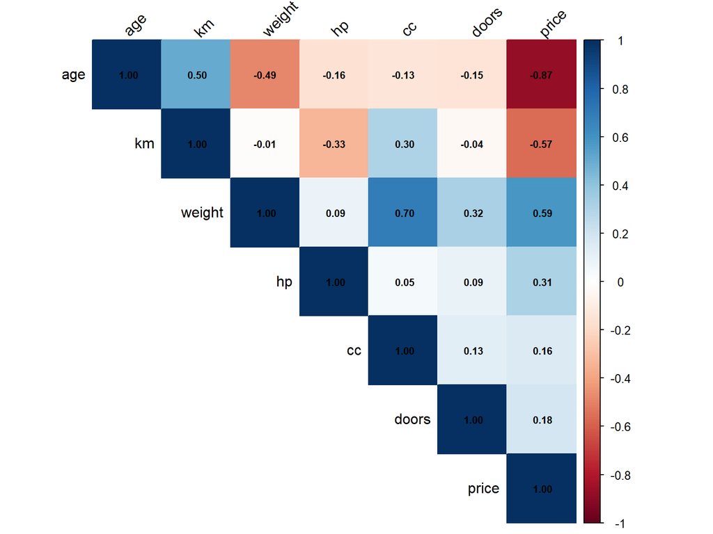

变量相关性矩阵

## 3.10 回归模型分析

我们建立了一个多元线性回归模型来预测汽车价格：

```
##
## Call:
## lm(formula = price ~ age + km + weight + hp + met_color + cc +
##     doors, data = car_data)
##
## Residuals:
##     Min      1Q  Median      3Q     Max
## -9258.1  -771.3    -5.4   739.8  8060.0
##
## Coefficients:
##               Estimate Std. Error t value Pr(>|t|)
## (Intercept) -1.209e+04  1.175e+03 -10.285  < 2e-16 ***
## age         -1.157e+02  2.647e+00 -43.729  < 2e-16 ***
## km          -1.705e-02  1.270e-03 -13.424  < 2e-16 ***
## weight       2.973e+01  1.295e+00  22.955  < 2e-16 ***
## hp           3.292e+01  2.515e+00  13.087  < 2e-16 ***
## met_color    4.612e+01  7.500e+01   0.615  0.53874
## cc          -2.741e+00  2.990e-01  -9.170  < 2e-16 ***
## doors       -1.181e+02  3.930e+01  -3.006  0.00269 **
## ---
## Signif. codes:  0 '***' 0.001 '**' 0.01 '*' 0.05 '.' 0.1 ' ' 1
##
## Residual standard error: 1318 on 1427 degrees of freedom
## Multiple R-squared:  0.8672, Adjusted R-squared:  0.8666
## F-statistic:  1332 on 7 and 1427 DF,  p-value: < 2.2e-16
```

回归系数表

[output not shown]

模型整体统计量

| r.squared | adj.r.squared | sigma | statistic | p.value | df | logLik | AIC | BIC | deviance | df.residual | nobs |
| --- | --- | --- | --- | --- | --- | --- | --- | --- | --- | --- | --- |
| 0.867 | 0.867 | 1318.165 | 1331.541 | 0 | 7 | -12341.2 | 24700.4 | 24747.82 | 2479496205 | 1427 | 1435 |

# 4 结论与建议

**模型解释力**：我们的回归模型解释了价格变异的86.7%（R² = 0.867），表明模型具有较好的预测能力。